# tutorial3

This tutorial builds on the autoregressive modelling in the self-directed work in week 2. To recap, you have fitted AR models of orders $p=0,1,2,3,4$, with linear trend, GFC trend break and quarterly dummies used as deterministic regressors. The estimation sample was 2000q1 to 2018 q4, and “one-step-ahead” forecasts were calculated for 2019q1. In this tutorial the analysis will be generalised by varying the estimation sample and the time period for which the forecasts are calculated. The formal statistic of “Root Mean Square Error” is introduced for forecast evaluation.

To get things started, here is the familiar code for setting up the data.

```r
rm(list=ls())
setwd("~/Library/CloudStorage/Dropbox/_TSAF/Week3/Tutorial3")
library(forecast)
dt <- read.csv("RetailSales.csv")
Retail_m <- ts(dt$Total, frequency=12, start=c(1982,4), end=c(2024,9))
Retail_q <- aggregate(Retail_m, nfrequency=4)
Y <- window(log(Retail_q), start=c(2000,1), end=c(2019,4))
Time <- time(Y)
gfc <- 2008.5
Time_postgfc <- 1*(Time>gfc)*(Time-gfc)
QD <- seasonaldummy(Y)
X <- cbind(Time, Time_postgfc, QD)
```

1. *Recursive Regression*.  
   Instead of relying on a single estimation sample and forecast period to evaluate models, we introduce “recursive regression” where we imagine starting out at the end of 2017 (i.e. using an estimation sample from 2000q1 to 2017q4) and forecasting 2018q1, and then stepping through time one quarter at a time, adding each new observation to the end of the estimation sample a quarter at a time. This exercise will be repeated until the end of the estimation sample is 2019q3 and the forecast period is 2019q4, so that 8 expanding estimation periods are used. The time periods are visualised below.

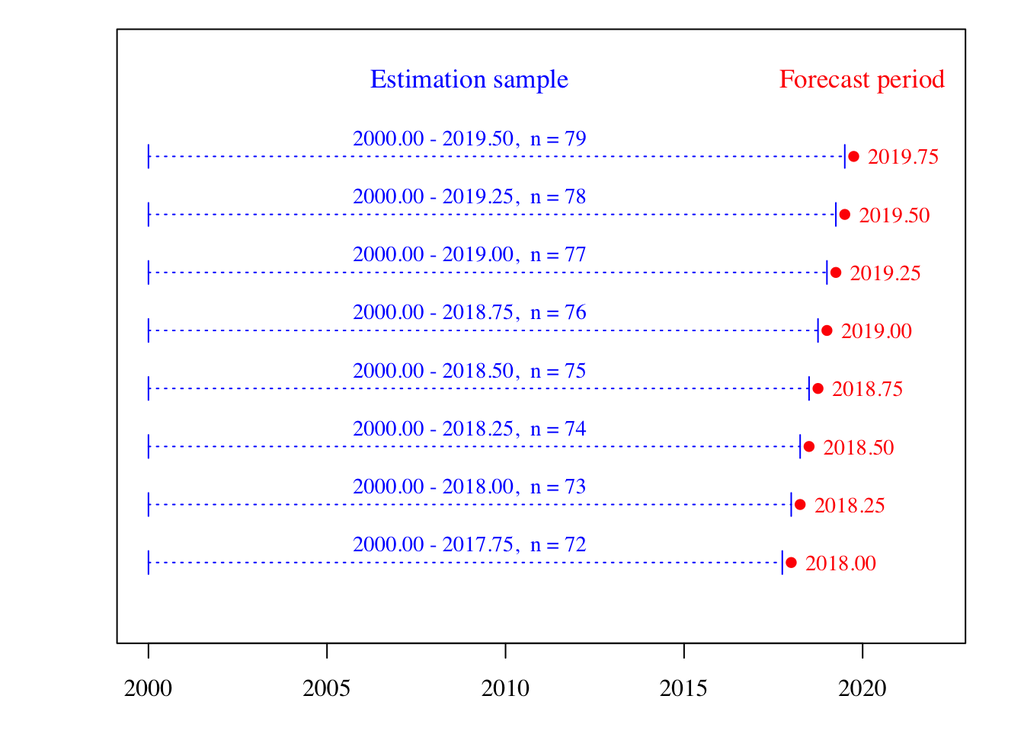

   For each of the above estimation samples, estimate AR(*p*) models for $p=0,1,2,3,4$ with trend, GFC trend break and quarterly dummies. Compute one-step-ahead forecasts and forecast errors for each model for the above forecast periods.

   Here are a few lines of R code to help get started:

   ```r
   Time_1 <- 2000.0  # First date of estimation sample
   Time_n <- 2017.75 # Last date of estimation sample

   # "for" loop to go through each estimation sample
   for (k in 1:8){

     # Observation indices for the estimation sample
     t_est <- which(Time>= Time_1 & Time<=Time_n)

     # Estimate AR1 model
     AR1 <- Arima(Y[t_est], order=c(1,0,0), xreg=X[t_est,])

     # Insert other AR(p) models here
     # Insert forecasting commands here

     # Add one quarter to end of estimation sample
     Time_n <- Time_n+0.25
   }
   ```

2. *Root mean square error*.
   For any time period $n$, the optimal one-step-ahead predictor of observation $Y_{n+1}$ is $E(Y_{n+1} | {\mathscr{F}}_{n})$. Suppose we have a model specification for the conditional expectation and an estimate for the model based on the estimation sample contained in the information set ${\mathscr{F}}_{n}$, giving a one-step-ahead forecast denoted $\widehat{E}(Y_{n+1} | {\mathscr{F}}_{n})$. The associated forecast error is
   $$\widehat{U}_{n+1} = Y_{n+1}-\widehat{E}(Y_{n+1} | {\mathscr{F}}_{n}).$$
   In recursive regression we carry out these forecasting calculations for a range of values of the sample size $n$; for example in question 1 $n=72,\ldots,79$. The “root mean squared error” in this context is defined as
   $$\text{R}{\color{orange}{\text{M}}}
   {\color{magenta}{\text{S}}}
   {\color{green}{\text{E}}}
   = \sqrt{{\color{orange}{\frac{1}{8}\sum_{n=72}^{79}}}
   {\color{green}{\widehat{U}_{n+1}}}^{\color{magenta}{2}}}$$
   The RMSE can be calculated for each model (in this case each AR order $p$). The model with smallest RMSE is deemed to provide the best forecasts. Which AR order produces the best forecasts across the recursive regressions in part 1?
3. *Rolling regression*.  
   An alternative to the recursive regression process in part 1 is “rolling regression”, in which both the starting date *and* the ending date of the estimation sample are moved forward time period at a time (as opposed to only the ending date moving forward in recursive regression). The effect of rolling regression is to maintain the same estimation sample size across the different models, while in recursive regression the estimation sample size is growing. (Neither recursive nor rolling regressions are always “correct”, they are simply different comparisons that may be appropriate in different circumstances.) The time periods for rolling regression are visualised below.

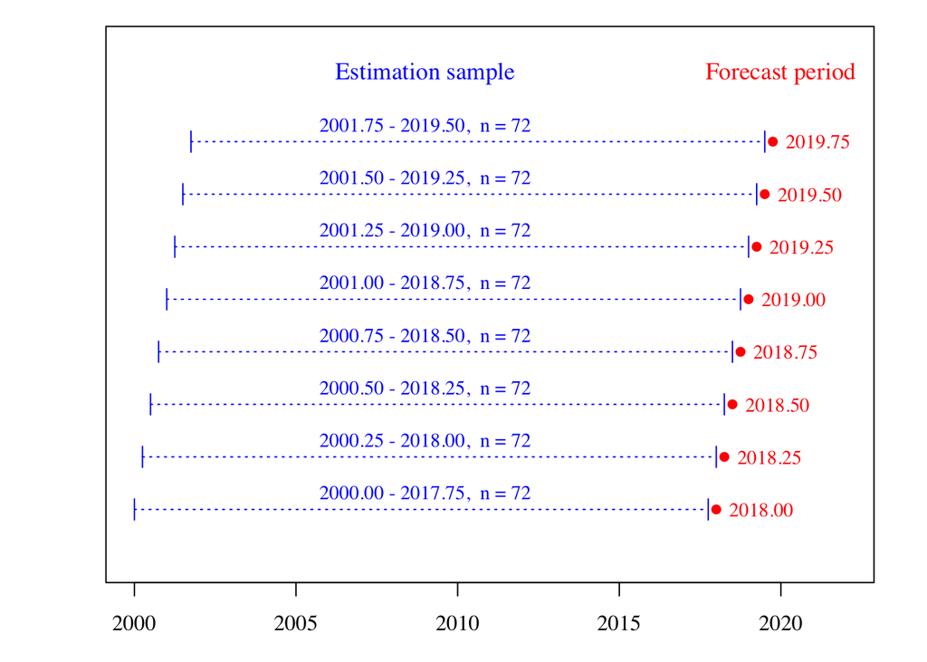

   For each of the above estimation samples, estimate AR(*p*) models for $p=0,1,2,3,4$ with trend, GFC trend break and quarterly dummies. Compute one-step-ahead forecasts and forecast errors for each model for the above forecast periods, and use RMSE to determine which autoregressive order produces the best rolling regression forecasts.